# Analysis of gene expresssion data from qPCR in R

FStamp

Last time modified: March 18, 2022

# Introduction

## What is this script for?

This is a simple R Markdown script for researchers interested in transitioning their qPCR analysis from GUI based platforms such as Prism or Excel to R. An example data set is provided (**qPCR_data.xlsx**) containing experimental data comparing the effect of a gene KO on the expression of 5 genes of interest.

## What information is required?

The following information is required for the analysis (see **qPCR_data.xlsx**):

- A list matching each tested sample with a condition (*condition*)
- Positional information of replicates on the plate (*replicates*)
- Positional information of samples on the plate (*samples*)
- Positional information of genes tested on the plate (*genes*)
- Raw data from the light cycler containing the Ct values per well (*data*)

The example data was acquired using QuantStudio 7 (384 well plate). When adapting this script, make sure to work with the same format (384 well). In case of using a different format (e.g. 96 well), you will have to change the import options accordingly.

## Analysis details

The workflow consists of 3 steps:

1. **Data import and formatting**: for easy implementation, the experimental data is imported directly from an Excel file containing the 5 sheets: *condition*, *replicates*, *samples*, *genes* and *data*.
2. **Data analysis**: this includes (A) calculation of normalized gene expression, (B) calculation of ∆∆Ct and Log2FFoldChange per sample and (C) selection of adequate statistics using a decision tree.
3. **Plotting**: visualization of data using ggplot2 with the results from the statistical tests indicating group differences.

# Setup

## Load libraries

```r
library(readxl) # the readxl is used to import data from excel (.xlsx)
library(tidyverse) # data wrangling
library(ggpubr) # required for stat_compare_means()
library(rstatix)  # https://github.com/kassambara/rstatix
library(stats) # required for padjust() function
library(car) # required for leveneTest() function
library(kableExtra) # scrollable tables in rendered html report
```

## Set global variables

**Set ID, subsets and reference genes**

Manually set the experimental “ID” and “Details”. These will be used for labeling results and plots.

```r
ID = "Experiment ID"
Details = "Brain WT vs KO"
```

**Define levels of the experimental condition**  
Set the order of levels of your experimental conditions. This will determine in which order the results are plotted.

```r
condition_levels <- c("WT", "KO") #set order of levels
```

**Define reference genes**  
Define which genes will be used as a reference for normalization of gene expression.

```r
HK1 = "reference_gene_1" #reference gene 1
HK2 = "reference_gene_2" #reference gene 2
HK <- c("reference_gene_1","reference_gene_2")  # vector of both reference genes
```

# Load data

**Set path to files**

```r
# Path to the qPCR_data.xlsx file
path <- file.path("..", "data", "qPCR_data.xlsx")
```

## Load Ct values from light cycler

Note: In case your light cycler results table contains a large header, you can skip these rows by using the skip argument.

```r
Ct_values <-
  read_excel(path, sheet = "data", skip = 0) %>%  # import sheet "data"
  dplyr::select("Well Position", "CT") %>%  # only select columns required for the analysis   # replace NA values
  mutate(CT = as.numeric(CT)) %>%  # set Ct as numeric
  mutate(CT = replace(CT, is.na(CT), "")) # replace NA values
```

## Load gene list

Import the positional information of which gene was tested in each well.

```r
genes <-
  read_excel(path, sheet = "genes", col_names = paste0("V", 1:24)) %>% # import sheet 1 and add provisional column headers
  mutate(row = LETTERS[1:16]) %>% # 16 rows: add the Letters to create positional information
  pivot_longer(cols = c(1:24)) %>% # 24 columns
  mutate(name = substring(name, 2)) %>% # This will create a positional coding, replacing the name "V" with a number
  mutate("Well Position" = paste(row, name, sep = ""), # Create a new ""Well Position"" column by pasting the values of the row and name columns together
         Gene = value) %>% # Create a "Gene" column, that contains values
  select("Well Position", Gene) %>%  # Select columns
  replace(is.na(.), "") %>%  # replace NA values
  dplyr::mutate(Gene = factor(Gene))  # convert Gene to factor
#head(genes)
```

## Load condition information

```r
condition  <-
  read_excel(path,
             sheet = "condition",
             col_types = "text",
             col_names = TRUE) %>%   # import sheet "condition"
  mutate(Condition = factor(Condition, levels = condition_levels)) # define "Condition" as factor and set levels
#head(Condition, n = 3)
```

## Load sample information

Load sheet containing positional information of samples, i.e. which sample was measured in which well.

```r
samples <-
  read_excel(
    path,
    sheet = "samples",
    col_types = "text",
    col_names = paste0("V", 1:24)
  ) %>% # import sheet "samples" and add provisional column headers
  mutate(row = LETTERS[1:16]) %>% # 16 rows: add the Letters to create positional information
  pivot_longer(cols = c(1:24)) %>% # 24 columns
  mutate(name = substring(name, 2)) %>% # This will create a positional coding, replacing the name "V" with a number
  mutate("Well Position" = paste(row, name, sep = ""),
         # Create a new ""Well Position"" column by pasting the values of the row and name columns together
         Sample = value) %>%  # Create a "Sample" column, that contains values
  select("Well Position", Sample) %>%   # Select columns
  replace(is.na(.), "") %>%  # replace NA values
  dplyr::mutate(Sample = factor(Sample))  # convert "Sample" to factor
#head(samples, n = 3)
```

## Load replicates information

Load sheet containing positional information of replicates, i.e. which replicate was measured in which well. Usually you will have 2-3 replicates per sample and gene.

```r
replicates <-
  read_excel(
    path,
    sheet = "replicates",
    col_types = "text",
    col_names = paste0("V", 1:24)
  ) %>% # import sheet "replicates" and add provisional column headers
  mutate(row = LETTERS[1:16]) %>% # 16 rows: add the Letters to create positional information
  pivot_longer(cols = c(1:24)) %>% # 24 columns.
  mutate(name = substring(name, 2)) %>%  # This will create a positional coding, replacing the name "V" with a number
  mutate("Well Position" = paste(row, name, sep = ""),
         # Create a new ""Well Position"" column by pasting the values of the row and name columns together
         Replicates = value) %>% # Create a "Replicate" column, that contains the  "value" values
  select("Well Position", Replicates) %>%
  replace(is.na(.), "") %>%  # replace NA values
  dplyr::mutate(Replicates = factor(Replicates))  # convert "Replicates" to factor
#head(replicates, n = 3)
```

## Merge data frames

Merge the *condition*, *replicates*, *samples*, *genes* and *CT* data frames into one data frame (df). “NTP” is used here to refer to “no template” containing control wells that are not used for the expression analysis.

```r
df <- merge(Ct_values, samples, by="Well Position") %>%
  merge(genes, by="Well Position") %>%
  merge(replicates, by = "Well Position") %>%
  merge(condition, by = "Sample") %>%
  filter(!CT == "Undetermined") %>%  # remove all undetermined wells
  mutate(CT = as.numeric(CT)) %>% # define CT as numeric
  filter(Sample != "NTP")  # drop NTP wells
#head(df, n = 3)
```

# Analysis

## Plot raw Ct values

Plot raw Ct values to identify outliers that result from technical issues (e.g. pippeting errors).

```r
Ct_plot <- df %>%
  ggplot(aes(Sample, CT, fill = Gene)) +
  geom_boxplot(alpha = 0.5) +
  geom_point(aes(fill = Gene), shape = 21,
             size = 1) +
  facet_wrap(Gene ~ Condition,
             scales = "free") + # split plot
  labs(x = "Sample", y = "CT") + #Axis labels
  ggtitle("CT values") + #Title
  theme(plot.title = element_text(hjust = 0.5)) + #Center title
  theme(legend.position = "right") + # position of legend
  theme_classic() + # classic theme
  theme(plot.title = element_text(size = 20, face = "bold"))    # increase title size

# set font size for facet label titles
# Save the plot
ggsave(
  "Ct_plot.pdf",
  plot = Ct_plot,
  device = "pdf",
  path = "../output/plots",
  scale = 1,
  units = "cm",
  dpi = 300,
  limitsize = TRUE,
)
```

```
## Saving 17.8 x 12.7 cm image
```

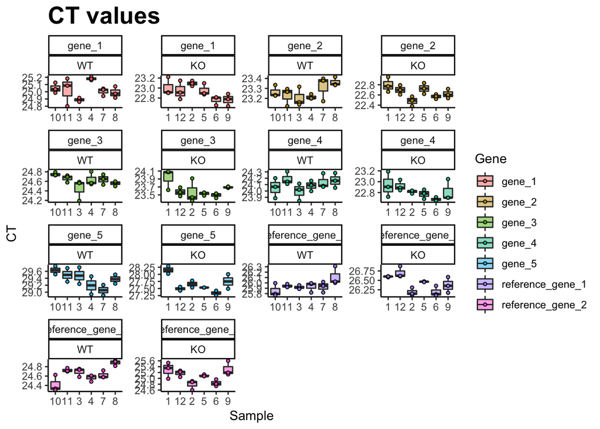

```r
#print to screen
print(Ct_plot)
```

## Calculation of normalized gene expression and Log2FoldChange

**Steps:**

1. Calculate mean CT values across technical replicates per sample and gene.
2. Calculate the geometric mean for the reference genes (HKs) you want to normalize the expression to.
3. Calculate DCT per sample: ∆Ct = Ct (gene of interest) – geometric mean of Ct (reference genes).
4. Calculate DDCT per sample: ∆∆Ct = ∆Ct (KO sample) – ∆Ct (WT samples average).
5. Calculate the relative fold gene expression (FoldChange) per sample: Fold gene expression = 2^-(∆∆Ct).
6. Transform LogFoldChange to log2 scale(Log2FoldChange) for statistical testing.

### (1) Calculate mean CT values acrtoss techical replicates per sample and gene

```r
df1 <- df %>%
  select(Sample, Gene, CT, Condition) %>% # columns of interest
  group_by(Gene, Sample, Condition) %>% # group values by Gene, Sample and Condition
  summarize(CT = mean(CT, na.rm = T)) %>% # use the summarize function (with z) to calculate the mean CT - overwriting the CT column. Remove NA values, since it stops the function from working
  pivot_wider(
    id_cols = c(Sample, Condition),
    names_from = Gene,
    values_from = CT
  ) # restructure the data frame to enable easy data manipulation
```

### (2) Calculate the geometric mean of the reference genes

```r
df2 <- df1 %>%
  gather(Gene, CT_mean,-c(Sample, Condition, all_of(HK)))  # convert to long format

# Calculate the geometric mean of the reference genes
geo_mean <- df2 %>%  select(HK1, HK2) %>%
  gather(key = Ref, value = value,-Sample) %>%
  group_by(Sample) %>%
  summarise(Geo_HK = exp(mean(log(value))))  # calculate geometric mean of HK genes in a new column
```

```
## Note: Using an external vector in selections is ambiguous.
## ℹ Use `all_of(HK1)` instead of `HK1` to silence this message.
## ℹ See <https://tidyselect.r-lib.org/reference/faq-external-vector.html>.
## Note: Using an external vector in selections is ambiguous.
## ℹ Use `all_of(HK2)` instead of `HK2` to silence this message.
## ℹ See <https://tidyselect.r-lib.org/reference/faq-external-vector.html>.
```

```r
# join df2 with geo_mean
df3 <- df2 %>%
inner_join(geo_mean, by = "Sample") # join with table containing geometric mean
```

### (3-6) Calculate ∆Ct, ∆∆Ct and Log2FoldChange

```r
df3 <- df3 %>%
mutate(DCT = CT_mean - Geo_HK) %>%  # calculate delta CT by subtracting the geometric mean of the house keeper genes from the individual sample CT means
  ungroup() %>%
  group_by(Gene, Condition) %>% # Group by Gene and Condition
  mutate(DCT_mean_WT = mean(DCT)) %>%  # Calculate DCT for each Condition. There might be a more elegant version to do this only for the WT animals
  ungroup() %>%
  group_by(Gene) %>%
  mutate(DDCT = DCT - DCT_mean_WT[Condition=="WT"]) %>% # subtract the DCT of the WT animals from the DCT of the individual samples (treated sample - untreated sample)
  mutate(FoldChange = 2^-(DDCT)) %>% # calculate FoldChange
  mutate(Log2FoldChange = log2(FoldChange)) # Transform onto log2 scale
```

### Optional: Calculate N number for labeling plots

Determine the N per condition and create a label to add to plots

```r
df3 <-df3 %>%
  group_by(Condition, Gene) %>%
   mutate( N = n()) %>% # Add N number
  mutate(Condition_label = paste0(Condition,"\n","(N=",N,")")) %>% # add annotation for plots
  mutate(Condition_label = as.factor(Condition_label)) %>%  # define annotation as factor
  mutate( Experiment = as.factor(ID)) %>%
     mutate(Gene_name = str_extract(Gene, "^.*?(?=_)"), .before = "Gene")  %>% # Add "clean" gene name for plotting
  mutate(Gene_name = ifelse(!is.na(Gene_name), Gene_name, Gene)) %>% # Create column containing only gene name by merging Gene with Gene_name if Gene_name contains "NA" values
  ungroup()
#head(df3)
```

## Statistical analysis

Gene expression values are often not normally distributed and heavily skewed. Specifically, down-regulated genes have a value between 0 and 1 (1 = no expression change), while up-regulated genes can have a value between 1 and positive infinity. By log transforming the gene expression ratios, they become symmetrical distributed around 0. Therefore, for the statistical analysis you should log-transform the expression data with the assumption that gene regulation and protein expression follow a log-normal distrubution.

### Calculate summary statistics per condition

```r
#subset data frame
df_stats <- df3 %>%
  select("Condition", "Log2FoldChange", "Gene")

df_sum <- df_stats %>%
  group_by(Condition, Gene) %>%   # group
  dplyr::summarise(
    n = n(),
    # how many observations
    mean = round(mean(Log2FoldChange), digits = 2),
    # calculate mean
    sd = round(sd(Log2FoldChange), digits = 2),
    #calculate sd
    p_shapiro = round(shapiro.test(Log2FoldChange)$p.value, digits =
                        3) # Shapiro-Wilk Test for normality
  ) %>%
  mutate(mean_sd = paste(mean, sd, sep = " \u00b1 "))  %>% # add a column containing mean and sd together, \u00b1 is the unicode for "+-"
  pivot_wider(names_from = Condition,
              # increase number of columns and decrease number of rows to make a nice summary table for presentation
              values_from = c(n, mean, sd, p_shapiro, mean_sd))
df_sum %>%
  kable("html") %>%
  kable_styling() %>%
  scroll_box(height = "200px")
```

| Gene | n_WT | n_KO | mean_WT | mean_KO | sd_WT | sd_KO | p_shapiro_WT | p_shapiro_KO | mean_sd_WT | mean_sd_KO |
| --- | --- | --- | --- | --- | --- | --- | --- | --- | --- | --- |
| gene_1 | 6 | 6 | 0 | 2.55 | 0.18 | 0.24 | 0.611 | 0.411 | 0 ± 0.18 | 2.55 ± 0.24 |
| gene_2 | 6 | 6 | 0 | 1.07 | 0.10 | 0.12 | 0.416 | 0.534 | 0 ± 0.1 | 1.07 ± 0.12 |
| gene_3 | 6 | 6 | 0 | 1.44 | 0.20 | 0.16 | 0.795 | 0.790 | 0 ± 0.2 | 1.44 ± 0.16 |
| gene_4 | 6 | 6 | 0 | 1.73 | 0.10 | 0.14 | 0.199 | 0.018 | 0 ± 0.1 | 1.73 ± 0.14 |
| gene_5 | 6 | 6 | 0 | 2.17 | 0.26 | 0.25 | 0.644 | 0.696 | 0 ± 0.26 | 2.17 ± 0.25 |

## Define the statistical tests that will be applied to the data

```r
## Define functions (levene/ t/ welch/ wilcox) that allow you to obtain the respective p-values
fun.levene.test <- function(x){
  a = leveneTest(Log2FoldChange ~ Condition, data = x)
  b = round(a[[3]][[1]], digits = 30)
}

fun.t.test <- function(x){
  a = t.test(Log2FoldChange ~ Condition, alternative = "two.sided", var.equal = TRUE, data = x)
  b = round(a[[3]], digits = 30)
}

fun.welch.test <- function(x){
  a = t.test(Log2FoldChange ~ Condition, alternative = "two.sided", var.equal = FALSE, data = x)
  b = round(a[[3]], digits = 30)
}

fun.wilcox.test <- function(x){
  a = wilcox.test(Log2FoldChange ~ Condition, exact=FALSE, data = x)
  b = round(a[[3]], digits = 30)
}
```

## Create a nested data frame and run statistical tests

```r
# Create a nested data frame that contains a list of lists for individual genes. Subsequently you will apply the test functions on each element (list) nested within the data frame.
df_nested <- df_stats%>%
  group_by(Gene) %>%
  nest()

# perform levene/ttest/welch/wilcox with each element of the nested data
df_com <- df_nested %>%
  mutate(
    levene = map_dbl(data, fun.levene.test),
    t = map_dbl(data, fun.t.test),
    welch = map_dbl(data, fun.welch.test),
    wilcox = map_dbl(data, fun.wilcox.test)
  )

# combine it with by columns
df_sumcom <- df_sum %>%
  left_join(df_com, by = "Gene")
```

## Define and run the decision tree

All tests will be run on the data, however the comparison decision tree will select and highlight the appropriate test that meets the requirements (distribution of data and variance).

```r
# Create the comparison decision tree
pipe_com_choice <- . %>%
  mutate(shapiro = ifelse(p_shapiro_WT < 0.05 |
                            p_shapiro_KO < 0.05, "*", "n.s.")) %>%
  mutate(
    compare_which = case_when(
      shapiro != "n.s."                 ~ "wilcox",
      shapiro == "n.s." & levene > 0.05 ~ "t",
      shapiro == "n.s." & levene < 0.05 ~ "welch"
    )
  )  %>%
  mutate(
    test_p = ifelse(
      compare_which == "wilcox",
      wilcox,
      ifelse(compare_which == "t", t, welch)
    ),
    p_star = case_when(
      test_p < 0.0001 ~ "****",
      test_p < 0.001 ~ "***",
      test_p < 0.01 ~ "**",
      test_p < 0.05 ~ "*",
      test_p > 0.05 ~ "n.s."
    )
  )


# apply the decision tree
df_sumcom_choice <- df_sumcom %>%
  pipe_com_choice()
```

## Multiple testing correction

Perform multiple testing correction using the Benjamini & Hochberg (1995) method.

```r
# calculate adjusted p values with the Benjamini & Hochberg (1995) method  ("BH" or its alias "fdr")
df_sumcom_choice <-df_sumcom_choice %>%
  mutate(padj = p.adjust(test_p, method = "BH"),n = length(Gene)) %>%
  mutate(padj_star = case_when(padj  < 0.0001 ~ "****",
                                padj  < 0.001 ~ "***",
                                padj < 0.01 ~ "**",
                                padj  < 0.05 ~ "*",
                                padj  > 0.05 ~ "n.s."))
```

## Create data frame with stats results

The column “compare_which” indicates which test was selected with the decision tree, with “test_p” and “padj” indicating the associated test values.

```r
results_stats_final <- df_sumcom_choice %>%
  select(!data) %>%
  mutate(ID = ID, Details = Details, Gene_name = str_extract(Gene, "^.*?(?=_)"), .before = "Gene") %>% # Add ID and Details info. Also Create a new column witht eh gene name that does not contain the primer ending
  mutate(Gene_name = ifelse(!is.na(Gene_name), Gene_name, Gene)) # Create column containing onlz gene name by merging Gene with Gene_name if Gene_name contains "NA" values

# save to table
write.csv(results_stats_final, paste("../output/tables/results_stats_final_",ID,".csv", sep = ""))

results_stats_final %>%
  kable("html") %>%
  kable_styling() %>%
  scroll_box(height = "200px")
```

ID

Details

Gene_name

Gene

n_WT

n_KO

mean_WT

mean_KO

sd_WT

sd_KO

p_shapiro_WT

p_shapiro_KO

mean_sd_WT

mean_sd_KO

levene

t

welch

wilcox

shapiro

compare_which

test_p

p_star

padj

n

padj_star

Experiment ID

Brain WT vs KO

gene

gene_1

6

6

0

2.55

0.18

0.24

0.611

0.411

0 ± 0.18

2.55 ± 0.24

0.6642901

0e+00

0e+00

0.0050749

n.s.

t

0.0000000

0.0000000

5

Experiment ID

Brain WT vs KO

gene

gene_2

6

6

0

1.07

0.10

0.12

0.416

0.534

0 ± 0.1

1.07 ± 0.12

0.5291009

0e+00

0e+00

0.0050749

n.s.

t

0.0000000

0.0000000

5

Experiment ID

Brain WT vs KO

gene

gene_3

6

6

0

1.44

0.20

0.16

0.795

0.790

0 ± 0.2

1.44 ± 0.16

0.9120702

1e-07

1e-07

0.0050749

n.s.

t

0.0000001

0.0000001

5

Experiment ID

Brain WT vs KO

gene

gene_4

6

6

0

1.73

0.10

0.14

0.199

0.018

0 ± 0.1

1.73 ± 0.14

0.8325973

0e+00

0e+00

0.0050749

wilcox

0.0050749

0.0050749

5

Experiment ID

Brain WT vs KO

gene

gene_5

6

6

0

2.17

0.26

0.25

0.644

0.696

0 ± 0.26

2.17 ± 0.25

0.8751581

0e+00

0e+00

0.0050749

n.s.

t

0.0000000

0.0000001

5

### Create a dataframe for plotting the manually calculated p values

This requires some cheating, since the stat_pvalue_manual() is usually used with predefined test functions. To use this function we are creating a data frame that looks like the output of these functions but contains our p values and p star symbols.

```r
# Create a data frame that contains group1, group2. .y.and condition_+label
stat.test <- df_stats %>%
  group_by(Gene) %>%
  mutate(group1 = paste0("WT", "\n", "(N=", 6, ")")) %>% # Create column containing WT x axis labels
  mutate(group2 = paste0("KO", "\n", "(N=", 6, ")")) %>% # Create column containing KO x axis labels
  get_y_position(formula = Log2FoldChange ~ Condition, fun = "max") %>%  # calculate the y.position
  add_x_position() %>% # add x positions 1 and 2
  mutate(Condition = "KO") %>% # a Condition column is required for mapping of the statistics though it seems to not mater how it is filled.
  left_join(results_stats_final, stat.testx, by = "Gene") %>% # use left_join to add the results from the manually calculated statistics
  distinct(Gene, .keep_all = TRUE) # Since the merging inflated the row number which now does not match the ggplot input, you need to select a subset. This subset contains all relevant details for each gene

stat.test %>%
  kable("html") %>%
  kable_styling() %>%
  scroll_box(height = "200px")
```

Gene

group1

group2

y.position

groups

xmin

xmax

Condition

ID

Details

Gene_name

n_WT

n_KO

mean_WT

mean_KO

sd_WT

sd_KO

p_shapiro_WT

p_shapiro_KO

mean_sd_WT

mean_sd_KO

levene

t

welch

wilcox

shapiro

compare_which

test_p

p_star

padj

n

padj_star

gene_1

WT

KO

3.125

WT, KO

2

1

KO

Experiment ID

Brain WT vs KO

gene

6

6

0

2.55

0.18

0.24

0.611

0.411

0 ± 0.18

2.55 ± 0.24

0.6642901

0e+00

0e+00

0.0050749

n.s.

t

0.0000000

0.0000000

5

gene_2

WT

KO

1.527

WT, KO

2

1

KO

Experiment ID

Brain WT vs KO

gene

6

6

0

1.07

0.10

0.12

0.416

0.534

0 ± 0.1

1.07 ± 0.12

0.5291009

0e+00

0e+00

0.0050749

n.s.

t

0.0000000

0.0000000

5

gene_3

WT

KO

2.004

WT, KO

2

1

KO

Experiment ID

Brain WT vs KO

gene

6

6

0

1.44

0.20

0.16

0.795

0.790

0 ± 0.2

1.44 ± 0.16

0.9120702

1e-07

1e-07

0.0050749

n.s.

t

0.0000001

0.0000001

5

gene_4

WT

KO

2.154

WT, KO

2

1

KO

Experiment ID

Brain WT vs KO

gene

6

6

0

1.73

0.10

0.14

0.199

0.018

0 ± 0.1

1.73 ± 0.14

0.8325973

0e+00

0e+00

0.0050749

wilcox

0.0050749

0.0050749

5

gene_5

WT

KO

2.839

WT, KO

2

1

KO

Experiment ID

Brain WT vs KO

gene

6

6

0

2.17

0.26

0.25

0.644

0.696

0 ± 0.26

2.17 ± 0.25

0.8751581

0e+00

0e+00

0.0050749

n.s.

t

0.0000000

0.0000001

5

# Plotting

## Set color and define a custom theme

**Define colors used for plotting**

Feel free to replace the Hex colors with color codes of your choosing.

```r
col <- c('#009ADC', '#FF1F5B')
```

**Define a custom theme/format to apply to the plots**

Defining a custom theme that can be applied to the plots. There are countless options that are not included and can be found online.

```r
theme_custom <- theme(text = element_text(family = "", size = 14),
                      panel.background  = element_blank(),
                      title = element_text(color = "#000000"),
                      plot.title = element_text(hjust = 0.5),
                      legend.text = element_text(color = "#000000"),
                      legend.background = element_blank(),
                      legend.key = element_blank(),
                      axis.text = element_text(color = "#000000"),
                      axis.line = element_line(color = "#000000"),
                      strip.background = element_blank(),
                      panel.border = element_rect(colour = "#000000", fill=NA))
```

### Plotted results with Log2FoldChange

Plot of all results faceted by gene.

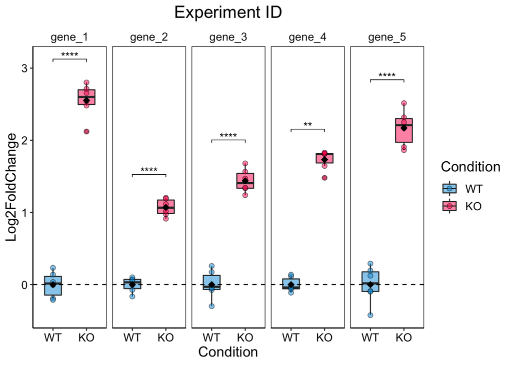

```r
all_genes_plot <- df3 %>%
  ggplot(aes(x = Condition, y = Log2FoldChange, fill = Condition)) +
  geom_boxplot(alpha = 0.5, width = .5) + # add box plot
  scale_fill_manual(values = col) + # change colors
  geom_point( # add scatter plot
    shape = 21,
    size = 2,
    position = position_dodge(width = .75),
    color = "black",
    alpha = 0.5
  ) +
geom_hline(yintercept = 0, linetype = "dashed") + # add horizontal line indicating 0
  ggtitle(paste(ID)) + # add title based on ID
  facet_wrap( ~ Gene, nrow = 1) + #facet wrap by Gene
  stat_summary( # calculate and add mean expression value as black diamond
    fun.y = mean,
    colour = "black",
    geom = "point",
    shape = 18,
    size = 3,
    position = position_dodge(width = .75),
    show.legend = FALSE
  ) +
  stat_pvalue_manual(stat.test, label = 'padj_star', tip.length = 0.01) + # add statistics
  theme_custom # apply custom theme formatting
# Save the plot
ggsave(
  "all_genes_plot.pdf",
  plot = all_genes_plot,
  device = "pdf",
  path = "../output/plots",
  height = 10,
  width = 15,
  scale = 1,
  units = "cm",
  dpi = 300,
  limitsize = TRUE,
)
#print to screen
print(all_genes_plot)
```

### Plot results for individual gene

The gene of interest is selected with the filter() function. IMPORTANT: Make sure to match your selection with the gene name in the stat_pvalue_manual() call that selects the fitting statistics results.  
Note: “Condition_label” containing the N number is used instead of “Condition” for the X-axis labels here.

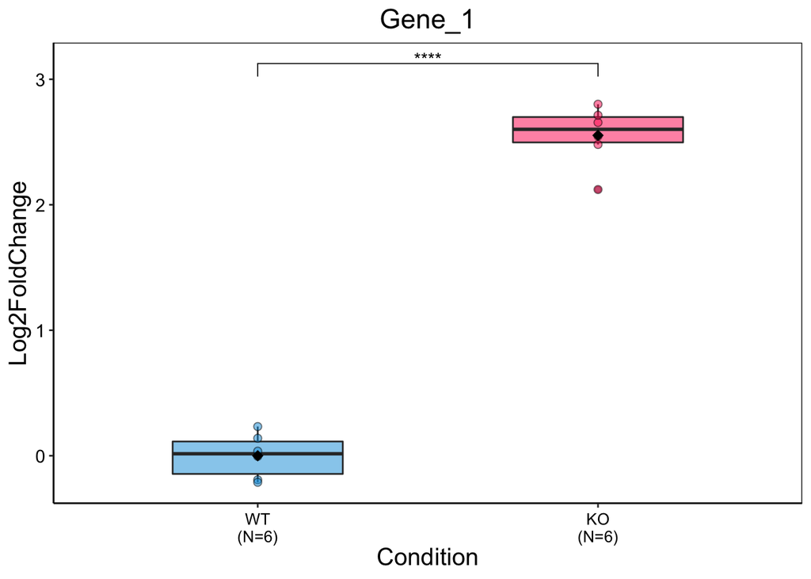

```r
gene_1_plot <- df3 %>%
  filter(Gene == "gene_1") %>%
  ggplot(aes(x = Condition_label, y = Log2FoldChange, fill = Condition)) +
  geom_boxplot(alpha = 0.5, width = .5) +
  scale_fill_manual(values = col) + #Change color to "col"
  geom_point(
    shape = 21,
    size = 2,
    position = position_dodge(width = .75),
    color = "black",
    alpha = 0.5
  ) +
  ggtitle("Gene_1") + # Title
  xlab("Condition") +
  theme(
    plot.title = element_text(hjust = 0.5),
    # Center title
    axis.text.x = element_text(
      size = 10,
      hjust = 0.5,
      vjust = 0.5
    ),
    axis.title = element_text(size = 15),
    legend.position = "none",
    strip.text = element_text(size = 10)
  ) + # set font size for facet label titles
  stat_summary(
    fun.y = mean,
    colour = "black",
    geom = "point",
    shape = 18,
    size = 3,
    position = position_dodge(width = .75),
    show.legend = FALSE
  ) +  # add the mean to the plots

  stat_pvalue_manual(filter(stat.test, Gene == "gene_1"), label = 'padj_star') + # select appropriate
    theme_custom # apply custom theme formatting
# Save the plot
ggsave(
  "gene_1_plot.pdf",
  plot = gene_1_plot,
  device = "pdf",
  path = "../output/plots",
  height = 10,
  width = 10,
  scale = 1,
  units = "cm",
  dpi = 300,
  limitsize = TRUE,
)
#print to screen
print(gene_1_plot)
```